# PART-1 : IDMB MOVIE REVIEWS SENTIMENT ANALYSIS

**•DOMAIN:** Digital content and entertainment industry

**•CONTEXT:** The objective of this project is to build a text classification model that analyses the customer's sentiments based on their reviews in the IMDB database. The model uses a complex deep learning model to build an embedding layer followed by a classification algorithm to analyse the sentiment of the customers.

**Importing All the Required Libraries**

```python
# Import Libraries
import numpy as np
import pandas as pd
!pip install kaggle --quiet
#import kaggle
import os
import re
import matplotlib.pyplot as plt
import seaborn as sns
import string

# Ignore the warnings
import warnings
warnings.filterwarnings("ignore")
```

```python
# Sklearn Libraries
from sklearn.preprocessing import OneHotEncoder,LabelEncoder
from sklearn.model_selection import train_test_split
from sklearn.feature_extraction.text import CountVectorizer,TfidfVectorizer
from sklearn.metrics import confusion_matrix
```

```python
# tensorflow Libraries
import tensorflow as tf
from tensorflow.keras.layers import Dense,LSTM,SimpleRNN,Dropout,BatchNormalization,Embedding,Flatten,SpatialDropout1D
from tensorflow.keras.models import Sequential
from tensorflow.keras.losses import CategoricalCrossentropy,BinaryCrossentropy
from tensorflow.keras.optimizers import Adam,SGD
from tensorflow.keras.metrics import Accuracy,Recall,Precision
from tensorflow.keras import datasets
from tensorflow.keras.preprocessing.sequence import pad_sequences
```

```python
#nltk libraries
import nltk
```

**Importing Dataset**

```python
#loading the data from keras datast
top_words = 10000
(X_train_list, y_train_list), (X_test_list, y_test_list) = datasets.imdb.load_data(num_words=top_words)
```

```
Downloading data from https://storage.googleapis.com/tensorflow/tf-keras-datasets/imdb.npz
```

```python
#getting text data from indexes
word_dict = datasets.imdb.get_word_index()
word_dict = { key:(value + 3) for key, value in word_dict.items() }
word_dict[''] = 0                                                    # Padding
word_dict['>'] = 1                                                   # Start
word_dict['?'] = 2                                                   # Unknown word
reverse_word_dict = { value:key for key, value in word_dict.items() }
print(' '.join(reverse_word_dict[id] for id in X_train_list[0]))
```

```
Downloading data from https://storage.googleapis.com/tensorflow/tf-keras-datasets/imdb_word_index.json
> this film was just brilliant casting location scenery story direction everyone's really suited the part they played and you could just imagine being there robert ? is an amazing actor and now the same being director ? father came from the same scottish island as myself so i loved the fact there wa…
```

```python
# Retrieve the word index file mapping words to indices
word_index = datasets.imdb.get_word_index()
# Reverse the word index to obtain a dict mapping indices to words
inverted_word_index = dict((i, word) for (word, i) in word_index.items())
# Decode the first sequence in the dataset
decoded_sequence = " ".join(inverted_word_index[i] for i in X_train_list[0])
```

```python
decoded_sequence
```

```
"the as you with out themselves powerful lets loves their becomes reaching had journalist of lot from anyone to have after out atmosphere never more room and it so heart shows to years of every never going and help moments or of every chest visual movie except her was several of enough more with is …
```

```python
y_train_list
```

```
array([1, 0, 0, ..., 0, 1, 0])
```

```python
# Making A Dataframe
train_df = pd.DataFrame()
train_text = []
test_text = []

for item in X_train_list :
    train_text.append(' '.join(reverse_word_dict[id] for id in item))

for item in X_test_list :
    test_text.append(' '.join(reverse_word_dict[id] for id in item))

#train_df = pd.DataFrame([ train_text,y_train_list],columns= ['Text','Label'])
#test_df = pd.DataFrame([ test_text,y_t_list],columns= ['Text','Label'])

train_df = pd.DataFrame({'Text':train_text,'Label':y_train_list})
test_df = pd.DataFrame({'Text':test_text,'Label':y_test_list})
```

```python
train_df['Text'][0]
```

```
"> this film was just brilliant casting location scenery story direction everyone's really suited the part they played and you could just imagine being there robert ? is an amazing actor and now the same being director ? father came from the same scottish island as myself so i loved the fact there w…
```

```python
test_df.head()
```

|  | Text | Label |
| --- | --- | --- |
| 0 | > please give this one a miss br br ? ? and th... | 0 |
| 1 | > this film requires a lot of patience because... | 1 |
| 2 | > many animation buffs consider ? ? the great ... | 1 |
| 3 | > i generally love this type of movie however ... | 0 |
| 4 | > like some other people wrote i'm a die hard ... | 1 |

```python
max_review_length = 500
X_train = pad_sequences(X_train_list, maxlen=max_review_length)
X_test = pad_sequences(X_test_list, maxlen=max_review_length)
```

# EDA

```python
#shape of X_train before and afre padding
X_train_list.shape , X_train.shape
```

```
((25000,), (25000, 500))
```

```python
len(X_train_list[0])
```

```
218
```

```python
#shape of X_test before and afre padding
X_test_list.shape, X_test.shape
```

```
((25000,), (25000, 500))
```

```python
#y_traina nd test shapes
y_train_list.shape,y_test_list.shape
```

```
((25000,), (25000,))
```

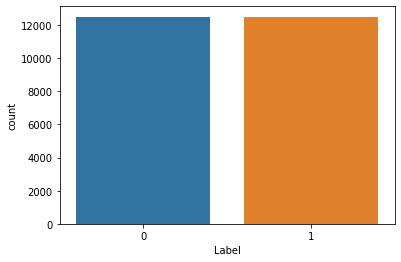

```python
# Plot of count of positive and negitive examples in Train
sns.countplot(train_df['Label'])
plt.show()
```

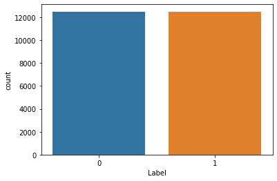

```python
# Plot of count of positive and negitive examples in Train
sns.countplot(test_df['Label'])
plt.show()
```

```python
[len(item) for item in X_train_list]
```

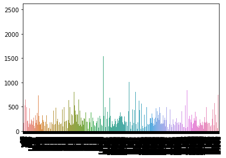

```python
# Barplot for all the Train Data and number of words present in them
plt.Figure(figsize=(50,30))
sns.barplot(x = np.arange(1,X_train.shape[0]+1),y = [len(item) for item in X_train_list[:]])
plt.xticks(rotation = 90)
plt.show()
```

### Model 1 [using Embeddings and dense layersrs ]

```python
embedding_vector_length = 32
model = Sequential()
model.add(Embedding(top_words, embedding_vector_length, input_length=max_review_length))
model.add(Flatten())
model.add(Dense(16, activation='relu'))
model.add(Dense(16, activation='relu'))
model.add(Dense(1, activation='sigmoid'))
model.compile(loss='binary_crossentropy', optimizer='adam', metrics=['accuracy'])
print(model.summary())
```

```
Model: "sequential"
_________________________________________________________________
 Layer (type)                Output Shape              Param #
=================================================================
 embedding (Embedding)       (None, 500, 32)           320000

 flatten (Flatten)           (None, 16000)             0

 dense (Dense)               (None, 16)                256016

 dense_1 (Dense)             (None, 16)                272

 dense_2 (Dense)             (None, 1)                 17

=================================================================
Total params: 576,305
Trainable params: 576,305
Non-trainable params: 0
_________________________________________________________________
None
```

```python
es = tf.keras.callbacks.EarlyStopping(monitor='val_loss', verbose=1, mode='min', patience=100)
hist = model.fit(X_train, y_train_list, validation_data=(X_test, y_test_list), epochs=10, batch_size=128, callbacks=[es], verbose=0)

_, train_acc = model.evaluate(X_train, y_train_list, verbose=1)
_, test_acc = model.evaluate(X_test, y_test_list, verbose=1)
print('Train: %.3f, Test: %.3f' % (train_acc, test_acc))
```

```
Train: 1.000, Test: 0.875
```

```
[]
```

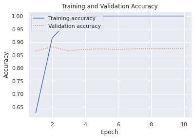

```python
sns.set()
acc = hist.history['accuracy']
val = hist.history['val_accuracy']
epochs = range(1, len(acc) + 1)

plt.plot(epochs, acc, '-', label='Training accuracy')
plt.plot(epochs, val, ':', label='Validation accuracy')
plt.title('Training and Validation Accuracy')
plt.xlabel('Epoch')
plt.ylabel('Accuracy')
plt.legend(loc='upper left')
plt.plot()
```

```
[]
```

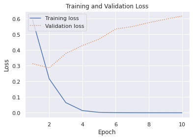

```python
sns.set()
loss = hist.history['loss']
val = hist.history['val_loss']
epochs = range(1, len(loss) + 1)

plt.plot(epochs, loss, '-', label='Training loss')
plt.plot(epochs, val, ':', label='Validation loss')
plt.title('Training and Validation Loss')
plt.xlabel('Epoch')
plt.ylabel('Loss')
plt.legend(loc='upper left')
plt.plot()
```

```python
y_pred1 = (model.predict(X_test) > 0.5).astype("int32").flatten()
confusion_matrix(y_test_list , y_pred1)
```

```
array([[10980,  1520],
       [ 1616, 10884]])
```

```python
np.round(model.predict(X_test[:2]),2)
```

```
array([[0.],
       [1.]], dtype=float32)
```

```python
y_test_list[:2]
```

```
array([0, 1])
```

### Model 2 [ Using Embeddings and Lstm ]

```python
#model2
embed_dim = 128
lstm_out = 196

model2 = Sequential()
model2.add(Embedding(top_words, embedding_vector_length, input_length=500))
model2.add(SpatialDropout1D(0.4))
model2.add(LSTM(64, dropout=0.2, recurrent_dropout=0.2))
model2.add(Dense(1,activation='sigmoid'))
model2.compile(loss = 'binary_crossentropy', optimizer='adam',metrics = ['accuracy'])
print(model2.summary())
```

[output not shown]

```python
batch_size = 32
hist = model2.fit(X_train, y_train_list, epochs = 5, batch_size=batch_size, verbose = 2)
```

```
782/782 - 517s - loss: 0.5715 - accuracy: 0.7162 - 517s/epoch - 661ms/step
782/782 - 511s - loss: 0.3875 - accuracy: 0.8370 - 511s/epoch - 654ms/step
782/782 - 512s - loss: 0.2898 - accuracy: 0.8842 - 512s/epoch - 654ms/step
782/782 - 512s - loss: 0.2358 - accuracy: 0.9093 - 512s/epoch - 654ms/step
782/782 - 513s - loss: 0.2060 - accuracy: 0.9250 - 513s/epoch - 656ms/step
```

```
<keras.callbacks.History at 0x7f3eed2a62d0>
```

```
[]
```

[figure not shown]

```python
sns.set()
acc = hist.history['accuracy']
val = hist.history['loss']
epochs = range(1, len(acc) + 1)

plt.plot(epochs, acc, '-', label='Training accuracy')
plt.plot(epochs, val, ':', label='Validation accuracy')
plt.title('Training and Loss')
plt.xlabel('Epoch')
plt.ylabel('Accuracy')
plt.legend(loc='upper left')
plt.plot()
```

```python
score,acc = model2.evaluate(X_test, y_test_list, verbose = 2, batch_size = batch_size)
print("Loss: %.2f" % (score))
print("acc: %.2f" % (acc))
```

[output not shown]

```python
y_pred2 = (model2.predict(X_test) > 0.5).astype("int32").flatten()
confusion_matrix(y_test_list , y_pred2)
```

```
array([[10552,  1948],
       [ 1170, 11330]])
```

```python
model2.predict(X_test[:2])
```

```
array([[0.04414362],
       [0.9914166 ]], dtype=float32)
```

```python
y_test_list[:2]
```

```
array([0, 1])
```

### model3 [ RNN and Embeddings]

```python
model3 = Sequential()
model3.add(Embedding(top_words, embedding_vector_length, input_length=500))
model3.add(SpatialDropout1D(0.4))
model3.add(SimpleRNN(64, dropout=0.2, recurrent_dropout=0.2))
model3.add(Dense(1,activation='sigmoid'))
model3.compile(loss = 'binary_crossentropy', optimizer='adam',metrics = ['accuracy'])
print(model3.summary())
```

```
Model: "sequential_5"
_________________________________________________________________
 Layer (type)                Output Shape              Param #
=================================================================
 embedding_5 (Embedding)     (None, 500, 32)           320000

 spatial_dropout1d_4 (Spatia  (None, 500, 32)          0
 lDropout1D)

 simple_rnn_1 (SimpleRNN)    (None, 64)                6208

 dense_7 (Dense)             (None, 1)                 65

=================================================================
Total params: 326,273
Trainable params: 326,273
Non-trainable params: 0
_________________________________________________________________
None
```

```python
batch_size = 32
hist = model3.fit(X_train, y_train_list, epochs = 10, batch_size=batch_size, verbose = 2)
```

[output not shown]

```
[]
```

[figure not shown]

```python
sns.set()
acc = hist.history['accuracy']
val = hist.history['loss']
epochs = range(1, len(acc) + 1)

plt.plot(epochs, acc, '-', label='Training accuracy')
plt.plot(epochs, val, ':', label='Training Loss')
plt.title('Training and Loss')
plt.xlabel('Epoch')
plt.ylabel('Accuracy')
plt.legend(loc='upper left')
plt.plot()
```

```python
score,acc = model3.evaluate(X_test, y_test_list, verbose = 2, batch_size = batch_size)
print("score: %.2f" % (score))
print("acc: %.2f" % (acc))
```

```
782/782 - 19s - loss: 0.7172 - accuracy: 0.5621 - 19s/epoch - 25ms/step
score: 0.72
acc: 0.56
```

```python
y_pred3 = (model3.predict(X_test) > 0.5).astype("int32").flatten()
confusion_matrix(y_test_list , y_pred2)
```

```
array([[10552,  1948],
       [ 1170, 11330]])
```

```python
model3.predict(X_test[:2])
```

```
array([[0.73910797],
       [0.853521  ]], dtype=float32)
```

```python
y_test_list[:2]
```

```
array([0, 1])
```

**Key Points**:

1. Used dense,RNN and Lstm models for performing sentiment analysis
2. Lstm has performmed better than Dense but the margn is very small
3. Need to hyper tune for better results
4. LSTM is able to give better results with less epoch

# PART-2 : Social media analytics

**•DOMAIN:** Social media analytics

**•CONTEXT:** Past studies in Sarcasm Detection mostly make use of Twitter datasets collected using hashtag based supervision but such datasets are noisy in terms of labels and language. Furthermore, many tweets are replies to other tweets and detecting sarcasm in these requires the availability of contextual tweets.In this hands-on project, the goal is to build a model to detect whether a sentence is sarcastic or not, using Bidirectional LSTMs.

**•DATA DESCRIPTION:** The dataset is collected from two news websites, theonion.com and huffingtonpost.com. This new dataset has the following advantages over the existing Twitter datasets:Since news headlines are written by professionals in a formal manner, there are no spelling mistakes and informal usage. This reduces the sparsity and also increases the chance of finding pre-trained embeddings.Furthermore, since the sole purpose of TheOnion is to publish sarcastic news, we get high-quality labels with much less noise as compared to Twitter datasets.Unlike tweets that reply to other tweets, the news headlines obtained are self-contained. This would help us in teasing apart the real sarcastic elementsContent: Each record consists of three attributes:is_sarcastic: 1 if the record is sarcastic otherwise 0headline: the headline of the news articlearticle_link: link to the original news article. Useful in collecting supplementary data

Reference: https://github.com/rishabhmisra/News-Headlines-Dataset-For-Sarcasm-Detection

**•PROJECT OBJECTIVE:** Build a sequential NLP classifier which can use input text parameters to determine the customer sentiments.

```python
#loading packages
from nltk.tokenize import word_tokenize,sent_tokenize
from tensorflow.keras.preprocessing.text import Tokenizer,text_to_word_sequence
from tensorflow.keras.preprocessing.sequence import pad_sequences

from tensorflow.keras.layers import Bidirectional
nltk.download('punkt')
```

```
True
```

```python
#loading Data
data = pd.read_json(path_or_buf = 'Sarcasm_Headlines_Dataset.json',orient = 'records',lines=True)
data.head()
```

|  | is_sarcastic | headline | article_link |
| --- | --- | --- | --- |
| 0 | 1 | thirtysomething scientists unveil doomsday clo... | https://www.theonion.com/thirtysomething-scien... |
| 1 | 0 | dem rep. totally nails why congress is falling... | https://www.huffingtonpost.com/entry/donna-edw... |
| 2 | 0 | eat your veggies: 9 deliciously different recipes | https://www.huffingtonpost.com/entry/eat-your-... |
| 3 | 1 | inclement weather prevents liar from getting t... | https://local.theonion.com/inclement-weather-p... |
| 4 | 1 | mother comes pretty close to using word 'strea... | https://www.theonion.com/mother-comes-pretty-c... |

```python
data['headline'][3]
```

```
'inclement weather prevents liar from getting to work'
```

```python
# dropping article link col
data_df = data.drop(columns = 'article_link')
```

```python
#getting charcter count of headline column
data_df['char_count'] = data_df['headline'].apply(lambda x: len(x))
```

```python
#getting word count
data_df['word_count'] = data_df['headline'].apply(lambda x : len(word_tokenize(x)))
```

```python
#getting word count
data_df['sent_count'] = data_df['headline'].apply(lambda x : len(sent_tokenize(x)))
```

```python
data_df.head()
```

|  | is_sarcastic | headline | char_count | word_count | sent_count |
| --- | --- | --- | --- | --- | --- |
| 0 | 1 | thirtysomething scientists unveil doomsday clo... | 61 | 8 | 1 |
| 1 | 0 | dem rep. totally nails why congress is falling... | 79 | 14 | 1 |
| 2 | 0 | eat your veggies: 9 deliciously different recipes | 49 | 8 | 1 |
| 3 | 1 | inclement weather prevents liar from getting t... | 52 | 8 | 1 |
| 4 | 1 | mother comes pretty close to using word 'strea... | 61 | 10 | 1 |

## EDA

```python
data_df.shape
```

```
(28619, 5)
```

```python
data_df['is_sarcastic'].value_counts()[0]
```

```
14985
```

**NOTE:** There is No imbalance in the dataset

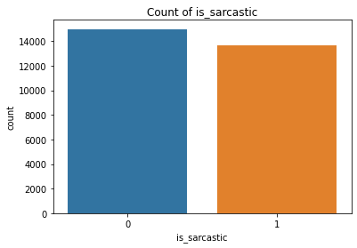

```python
sns.countplot(data_df['is_sarcastic'])
plt.title('Count of is_sarcastic')
plt.show()
```

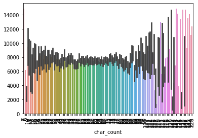

```python
%matplotlib inline
plt.Figure(figsize = (100,50))
sns.barplot(x = data_df[data_df['is_sarcastic']== 0]['char_count'],y = np.arange(0,data_df['is_sarcastic'].value_counts()[0]))
plt.xticks(rotation = 90)
plt.show()
```

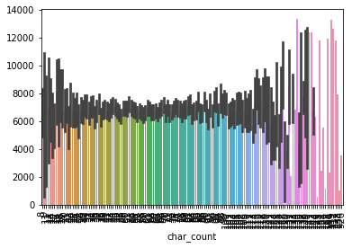

```python
plt.Figure(figsize = (100,50))
sns.barplot(x = data_df[data_df['is_sarcastic']== 1]['char_count'],y = np.arange(0,data_df['is_sarcastic'].value_counts()[1]))
plt.xticks(rotation = 90)
plt.show()
```

## Text cleaning and preprocessing

### Initializing parameter values

```python
top_words = 10000
seq_len = 30 #int(data_df['word_count'].median())
print(seq_len)
embedding_size = 50 #using 50 dimensional glove vectors for embeddings
```

```
30
```

### Applied `tensorflow.keras` Tokenizer and get indices for words

- Initialized Tokenizer object with number of words as 10000
- Fit the tokenizer object on headline column
- Converted the text to sequence

```python
t = Tokenizer( top_words)
t.fit_on_texts(data_df['headline'])

word_index_dict = t.word_index

vocab_size = len(word_index_dict) + 1

vocab_size
```

```
30885
```

```python
list(t.word_index.items())[:5]
```

```
[('to', 1), ('of', 2), ('the', 3), ('in', 4), ('for', 5)]
```

### Pad sequences

- Pad each example with seq_lenth to make every sample of same size

```python
sequence = t.texts_to_sequences(data['headline'])
sequence[0:5]
```

```
[[354, 3166, 7473, 2643, 2, 660, 1118],
 [7474, 1774, 757, 3167, 46, 238, 10, 1843, 1047, 7, 1527, 2153, 1844],
 [862, 32, 261, 646, 1483],
 [1593, 6417, 5664, 15, 142, 1, 151],
 [471, 494, 321, 921, 1, 571, 549, 6418]]
```

```python
pad_sequence = pad_sequences(sequences=sequence, maxlen=seq_len)
pad_sequence[:5]
```

```
array([[   0,    0,    0,    0,    0,    0,    0,    0,    0,    0,    0,
           0,    0,    0,    0,    0,    0,    0,    0,    0,    0,    0,
           0,  354, 3166, 7473, 2643,    2,  660, 1118],
       [   0,    0,    0,    0,    0,    0,    0,    0,    0,    0,    0,
           0,    0,    0,    0,    0,    0, 7474, 1774,  757, 3167,   46,
         238,   10, 1843, 1047,    7, 1527, 2153, 1844],
       [   0,    0,    0,    0,    0,    0,    0,    0,    0,    0,    0,
           0,    0,    0,    0,    0,    0,    0,    0,    0,    0,    0,
           0,    0,    0,  862,   32,  261,  646, 1483],
       [   0,    0,    0,    0,    0,    0,    0,    0,    0,    0,    0,
           0,    0,    0,    0,    0,    0,    0,    0,    0,    0,    0,
           0, 1593, 6417, 5664,   15,  142,    1,  151],
       [   0,    0,    0,    0,    0,    0,    0,    0,    0,    0,    0,
           0,    0,    0,    0,    0,    0,    0,    0,    0,    0,    0,
         471,  494,  321,  921,    1,  571,  549, 6418]], dtype=int32)
```

# getting pretrained glove vector for embedding

```python
!wget http://nlp.stanford.edu/data/glove.6B.zip
!unzip -r glove*.zip
```

[output not shown]

```python
#using 50 dimen vectors
glove_file = '/content//glove.6B.50d.txt'
```

```python
embeddings_vector = {}
f = open(glove_file)
for line in f:
    values = line.split()
    word = values[0]
    vector = np.asarray(values[1:], dtype='float32')
    embeddings_vector[word] = vector
f.close()
```

```python
len(embeddings_vector.keys())
```

```
400000
```

> so there 4 lakh words but we need only 30885 words so we will filter out those unwanted words

```python
# create a weight matrix for words in training docs
embedding_matrix = np.zeros((vocab_size, 50))

for word, i in t.word_index.items():
	embedding_vector = embeddings_vector.get(word)
	if embedding_vector is not None:
		embedding_matrix[i] = embedding_vector
```

```python
#splitting the data into training and testing
X_train,X_test,y_train,y_test = train_test_split(pad_sequence,data_df['is_sarcastic'],random_state =1,test_size = 0.2,stratify= data_df['is_sarcastic'])
```

```python
X_train.shape
```

```
(22895, 30)
```

```python
X_test.shape
```

```
(5724, 30)
```

```python
y_train.value_counts()
```

```
0    11988
1    10907
Name: is_sarcastic, dtype: int64
```

# Model Bulding

```python
# Model 1 using Rnn
model = Sequential()
#Non-trainable embeddidng layer
model.add(Embedding(vocab_size, embedding_size, weights=[embedding_matrix], input_length=seq_len))
#LSTM
model.add(SimpleRNN(units=128 ,dropout=0.2, recurrent_dropout=0.2))
model.add(Flatten())
model.add(Dense(1, activation='sigmoid'))
model.summary()
```

```
Model: "sequential_3"
_________________________________________________________________
 Layer (type)                Output Shape              Param #
=================================================================
 embedding (Embedding)       (None, 30, 50)            1544250

 simple_rnn (SimpleRNN)      (None, 128)               22912

 flatten (Flatten)           (None, 128)               0

 dense (Dense)               (None, 1)                 129

=================================================================
Total params: 1,567,291
Trainable params: 1,567,291
Non-trainable params: 0
_________________________________________________________________
```

```python
model.compile(optimizer=Adam(lr = 0.01), loss='binary_crossentropy', metrics=['acc'])
```

```python
history = model.fit(x=X_train, y=y_train, validation_data=(X_test, y_test), epochs = 10, verbose = 1)
```

```
[]
```

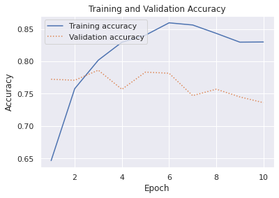

```python
sns.set()
acc = history.history['acc']
val = history.history['val_acc']
epochs = range(1, len(acc) + 1)

plt.plot(epochs, acc, '-', label='Training accuracy')
plt.plot(epochs, val, ':', label='Validation accuracy')
plt.title('Training and Validation Accuracy')
plt.xlabel('Epoch')
plt.ylabel('Accuracy')
plt.legend(loc='upper left')
plt.plot()
```

```
[]
```

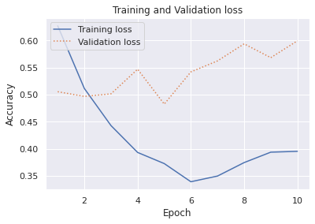

```python
sns.set()
acc = history.history['loss']
val = history.history['val_loss']
epochs = range(1, len(acc) + 1)

plt.plot(epochs, acc, '-', label='Training loss')
plt.plot(epochs, val, ':', label='Validation loss')
plt.title('Training and Validation loss')
plt.xlabel('Epoch')
plt.ylabel('Accuracy')
plt.legend(loc='upper left')
plt.plot()
```

```python
# Acc Score
scores = model.evaluate(X_test, y_test, verbose=0)
print("Accuracy: %.5f%%" % (scores[1]*100))
```

```
Accuracy: 73.61985%
```

```python
y_pred1= model.predict(X_test)>0.5
confusion_matrix(y_test,y_pred1)
```

```
array([[2283,  714],
       [ 796, 1931]])
```

```python
tf.keras.backend.clear_session()
model = Sequential()
#Non-trainable embeddidng layer
model.add(Embedding(vocab_size, embedding_size, weights=[embedding_matrix], input_length=seq_len))
model.add(SimpleRNN(units=128 ,dropout=0.2, recurrent_dropout=0.2))
model.add(Flatten())
model.add(Dense(1, activation='sigmoid'))
model.summary()
```

```
Model: "sequential"
_________________________________________________________________
 Layer (type)                Output Shape              Param #
=================================================================
 embedding (Embedding)       (None, 30, 50)            1544250

 simple_rnn (SimpleRNN)      (None, 128)               22912

 flatten (Flatten)           (None, 128)               0

 dense (Dense)               (None, 1)                 129

=================================================================
Total params: 1,567,291
Trainable params: 1,567,291
Non-trainable params: 0
_________________________________________________________________
```

```python
#training using SGD optimizer
model.compile(optimizer=SGD(), loss='binary_crossentropy', metrics=['acc'])
```

```python
history = model.fit(x=X_train, y=y_train, validation_data=(X_test, y_test), epochs = 10, verbose = 1)
```

```python
# Acc Score
scores = model.evaluate(X_test, y_test, verbose=0)
print("Accuracy: %.5f%%" % (scores[1]*100))
```

```
Accuracy: 73.95178%
```

```python
y_pred1= model.predict(X_test)>0.5
confusion_matrix(y_test,y_pred1)
```

```
array([[2325,  672],
       [ 819, 1908]])
```

```
[]
```

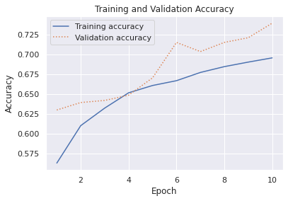

```python
sns.set()
acc = history.history['acc']
val = history.history['val_acc']
epochs = range(1, len(acc) + 1)

plt.plot(epochs, acc, '-', label='Training accuracy')
plt.plot(epochs, val, ':', label='Validation accuracy')
plt.title('Training and Validation Accuracy')
plt.xlabel('Epoch')
plt.ylabel('Accuracy')
plt.legend(loc='upper left')
plt.plot()
```

```
[]
```

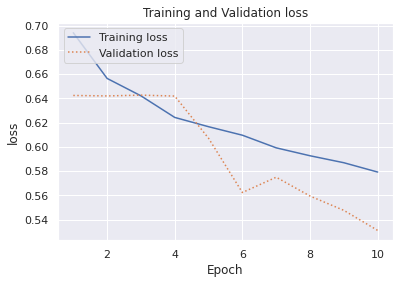

```python
sns.set()
acc = history.history['loss']
val = history.history['val_loss']
epochs = range(1, len(acc) + 1)

plt.plot(epochs, acc, '-', label='Training loss')
plt.plot(epochs, val, ':', label='Validation loss')
plt.title('Training and Validation loss')
plt.xlabel('Epoch')
plt.ylabel('loss')
plt.legend(loc='upper left')
plt.plot()
```

## Model 2 LSTM

```python
model2 = Sequential()
#Non-trainable embeddidng layer
model2.add(Embedding(vocab_size, embedding_size, weights=[embedding_matrix], input_length=seq_len))
#LSTM
model2.add(LSTM(units = 128 ,dropout=0.2, recurrent_dropout=0.2))
model2.add(Flatten())
model2.add(Dense(1, activation='sigmoid'))
model2.summary()
```

```
Model: "sequential_1"
_________________________________________________________________
 Layer (type)                Output Shape              Param #
=================================================================
 embedding_1 (Embedding)     (None, 30, 50)            1544250

 lstm (LSTM)                 (None, 128)               91648

 flatten_1 (Flatten)         (None, 128)               0

 dense_1 (Dense)             (None, 1)                 129

=================================================================
Total params: 1,636,027
Trainable params: 1,636,027
Non-trainable params: 0
_________________________________________________________________
```

```python
model2.compile(optimizer=Adam(lr = 0.01), loss='binary_crossentropy', metrics=['acc'])
```

```python
history = model2.fit(x=X_train, y=y_train, validation_data=(X_test, y_test), epochs = 10, verbose = 1)
```

```
[]
```

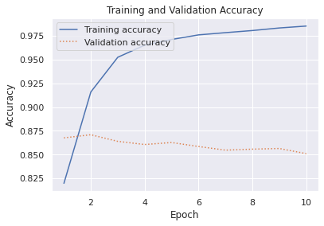

```python
sns.set()
acc = history.history['acc']
val = history.history['val_acc']
epochs = range(1, len(acc) + 1)

plt.plot(epochs, acc, '-', label='Training accuracy')
plt.plot(epochs, val, ':', label='Validation accuracy')
plt.title('Training and Validation Accuracy')
plt.xlabel('Epoch')
plt.ylabel('Accuracy')
plt.legend(loc='upper left')
plt.plot()
```

```
[]
```

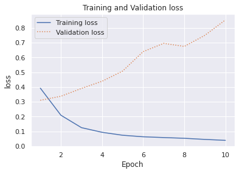

```python
sns.set()
acc = history.history['loss']
val = history.history['val_loss']
epochs = range(1, len(acc) + 1)

plt.plot(epochs, acc, '-', label='Training loss')
plt.plot(epochs, val, ':', label='Validation loss')
plt.title('Training and Validation loss')
plt.xlabel('Epoch')
plt.ylabel('loss')
plt.legend(loc='upper left')
plt.plot()
```

```python
# Acc Score
scores = model2.evaluate(X_test, y_test, verbose=0)
print("Accuracy: %.5f%%" % (scores[1]*100))
```

```
Accuracy: 85.09783%
```

```python
y_pred2= model2.predict(X_test)>0.5
confusion_matrix(y_test,y_pred2)
```

```
array([[2598,  399],
       [ 454, 2273]])
```

```python
tf.keras.backend.clear_session()
model2 = Sequential()
#Non-trainable embeddidng layer
model2.add(Embedding(vocab_size, embedding_size, weights=[embedding_matrix], input_length=seq_len))
#LSTM
model2.add(LSTM(units = 128 ,dropout=0.2, recurrent_dropout=0.2))
model2.add(Flatten())
model2.add(Dense(1, activation='sigmoid'))
model2.summary()
```

```
Model: "sequential"
_________________________________________________________________
 Layer (type)                Output Shape              Param #
=================================================================
 embedding (Embedding)       (None, 30, 50)            1544250

 lstm (LSTM)                 (None, 128)               91648

 flatten (Flatten)           (None, 128)               0

 dense (Dense)               (None, 1)                 129

=================================================================
Total params: 1,636,027
Trainable params: 1,636,027
Non-trainable params: 0
_________________________________________________________________
```

```python
model2.compile(optimizer=SGD(), loss='binary_crossentropy', metrics=['acc'])
```

```python
history = model2.fit(x=X_train, y=y_train, validation_data=(X_test, y_test), epochs = 10, verbose = 1)
```

```
[]
```

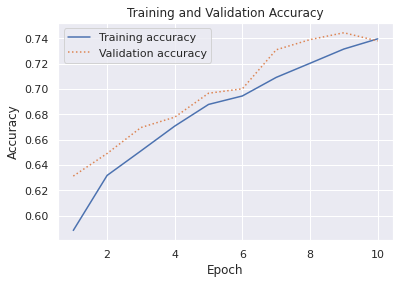

```python
sns.set()
acc = history.history['acc']
val = history.history['val_acc']
epochs = range(1, len(acc) + 1)

plt.plot(epochs, acc, '-', label='Training accuracy')
plt.plot(epochs, val, ':', label='Validation accuracy')
plt.title('Training and Validation Accuracy')
plt.xlabel('Epoch')
plt.ylabel('Accuracy')
plt.legend(loc='upper left')
plt.plot()
```

```
[]
```

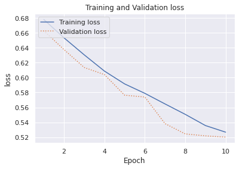

```python
sns.set()
acc = history.history['loss']
val = history.history['val_loss']
epochs = range(1, len(acc) + 1)

plt.plot(epochs, acc, '-', label='Training loss')
plt.plot(epochs, val, ':', label='Validation loss')
plt.title('Training and Validation loss')
plt.xlabel('Epoch')
plt.ylabel('loss')
plt.legend(loc='upper left')
plt.plot()
```

```python
# Acc Score
scores = model2.evaluate(X_test, y_test, verbose=0)
print("Accuracy: %.5f%%" % (scores[1]*100))
```

```
Accuracy: 73.79455%
```

```python
y_pred2= model2.predict(X_test)>0.5
confusion_matrix(y_test,y_pred2)
```

```
array([[2699,  298],
       [1202, 1525]])
```

## Model 3 [Bidirectional]

```python
model3 = Sequential()
#Non-trainable embeddidng layer
model3.add(Embedding(vocab_size, embedding_size, weights=[embedding_matrix], input_length=seq_len))
#BidirectionalLSTM
model3.add(Bidirectional(LSTM(units=128 ,dropout = 0.5,return_sequences=True)))
model3.add(Flatten())
model3.add(Dense(1, activation='sigmoid'))
model3.summary()
```

```
Model: "sequential_1"
_________________________________________________________________
 Layer (type)                Output Shape              Param #
=================================================================
 embedding_1 (Embedding)     (None, 30, 50)            1544250

 bidirectional (Bidirectiona  (None, 30, 256)          183296
 l)

 flatten_1 (Flatten)         (None, 7680)              0

 dense_1 (Dense)             (None, 1)                 7681

=================================================================
Total params: 1,735,227
Trainable params: 1,735,227
Non-trainable params: 0
_________________________________________________________________
```

```python
model3.compile(optimizer=Adam(lr = 0.01), loss='binary_crossentropy', metrics=['acc'])
```

```python
history = model3.fit(x=X_train, y=y_train, validation_data=(X_test, y_test), epochs = 10, verbose = 1)
```

```
[]
```

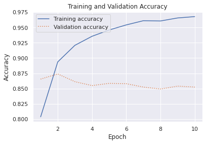

```python
sns.set()
acc = history.history['acc']
val = history.history['val_acc']
epochs = range(1, len(acc) + 1)

plt.plot(epochs, acc, '-', label='Training accuracy')
plt.plot(epochs, val, ':', label='Validation accuracy')
plt.title('Training and Validation Accuracy')
plt.xlabel('Epoch')
plt.ylabel('Accuracy')
plt.legend(loc='upper left')
plt.plot()
```

```
[]
```

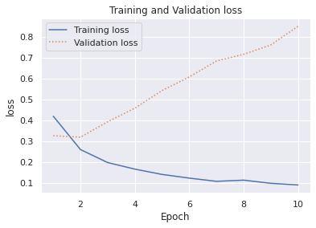

```python
sns.set()
acc = history.history['loss']
val = history.history['val_loss']
epochs = range(1, len(acc) + 1)

plt.plot(epochs, acc, '-', label='Training loss')
plt.plot(epochs, val, ':', label='Validation loss')
plt.title('Training and Validation loss')
plt.xlabel('Epoch')
plt.ylabel('loss')
plt.legend(loc='upper left')
plt.plot()
```

```python
# Acc Score
scores = model3.evaluate(X_test, y_test, verbose=0)
print("Accuracy: %.5f%%" % (scores[1]*100))
```

```
Accuracy: 85.23760%
```

```python
y_pred2= model3.predict(X_test)>0.5
confusion_matrix(y_test,y_pred2)
```

```
array([[2615,  382],
       [ 463, 2264]])
```

```python
tf.keras.backend.clear_session()
model3 = Sequential()
#Non-trainable embeddidng layer
model3.add(Embedding(vocab_size, embedding_size, weights=[embedding_matrix], input_length=seq_len))
#BidirectionalLSTM
model3.add(Bidirectional(LSTM(units=128 ,dropout = 0.5,return_sequences=True)))
model3.add(Flatten())
model3.add(Dense(1, activation='sigmoid'))
model3.summary()
```

```
Model: "sequential"
_________________________________________________________________
 Layer (type)                Output Shape              Param #
=================================================================
 embedding (Embedding)       (None, 30, 50)            1544250

 bidirectional (Bidirectiona  (None, 30, 256)          183296
 l)

 flatten (Flatten)           (None, 7680)              0

 dense (Dense)               (None, 1)                 7681

=================================================================
Total params: 1,735,227
Trainable params: 1,735,227
Non-trainable params: 0
_________________________________________________________________
```

```python
model3.compile(optimizer=SGD(), loss='binary_crossentropy', metrics=['acc'])
```

```python
history = model3.fit(x=X_train, y=y_train, validation_data=(X_test, y_test), epochs = 10, verbose = 1)
```

```
[]
```

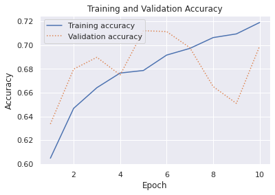

```python
sns.set()
acc = history.history['acc']
val = history.history['val_acc']
epochs = range(1, len(acc) + 1)

plt.plot(epochs, acc, '-', label='Training accuracy')
plt.plot(epochs, val, ':', label='Validation accuracy')
plt.title('Training and Validation Accuracy')
plt.xlabel('Epoch')
plt.ylabel('Accuracy')
plt.legend(loc='upper left')
plt.plot()
```

```
[]
```

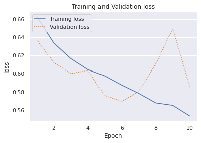

```python
sns.set()
acc = history.history['loss']
val = history.history['val_loss']
epochs = range(1, len(acc) + 1)

plt.plot(epochs, acc, '-', label='Training loss')
plt.plot(epochs, val, ':', label='Validation loss')
plt.title('Training and Validation loss')
plt.xlabel('Epoch')
plt.ylabel('loss')
plt.legend(loc='upper left')
plt.plot()
```

```python
# Acc Score
scores = model3.evaluate(X_test, y_test, verbose=0)
print("Accuracy: %.5f%%" % (scores[1]*100))
```

```
Accuracy: 69.91614%
```

```python
y_pred2= model3.predict(X_test)>0.5
confusion_matrix(y_test,y_pred2)
```

```
array([[1607, 1390],
       [ 332, 2395]])
```